# **Location-scale Meta-analysis and Meta-regression as a Tool to Capture Large-scale Changes in Biological and Methodological Heterogeneity: a Spotlight on Heteroscedasticity**

### 7.2.3 Multilevel location-scale meta-regression with a continuous moderator

Fortunately, both `brms` and `lsmeta` can fit a multilevel location-scale meta-regression with a continuous moderator. Therefore, we will illustrate both.

#### 7.2.3.1 `brms`

Add `elevation_log` as the moderator to both location and scale parts:

```r
# SMD = d
form_mr3 <- bf(yi
            ~ 1 + elevation_log +
              (1|study_ID) + # this is u
              (1|gr(es_ID, cov = vcv)), # this is m
            sigma ~ 1 + elevation_log
)

# create priorss
prior_mr3 <- default_prior(form_mr3,
                        data = dat,
                        data2 = list(vcv = vcv),
                        family = gaussian()
)
# fixing the variance to 1 (meta-analysis)
prior_mr3$prior[5] = "constant(1)"
prior_mr3

# fit model
fit_mr3 <- brm(form_mr3,
            data = dat,
            data2 = list(vcv = vcv),
            chains = 2,
            cores = 2,
            iter = 6000,
            warmup = 3000,
            prior = prior_mr3,
            control = list(adapt_delta = 0.95, max_treedepth = 15)
)

# save this as rds
saveRDS(fit_mr3, here("Rdata", "fit_mr3.rds"))
```

Consistent with the original finding, we see that the intraspecific leaf trait of higher elevation will have a higher value (`0.05, 95% CI: 0.01 to 0.08`). Apart this confirmation, we also find the intraspecific leaf trait in higher elevation is more variable than that in lower elevation (`0.29, 95% CI: 0.12 to 0.46`):

```r
fit_mr3 <- readRDS(here("Rdata", "fit_mr3.rds"))
summary(fit_mr3)
##  Family: gaussian
##   Links: mu = identity; sigma = log
## Formula: yi ~ 1 + elevation_log + (1 | study_ID) + (1 | gr(es_ID, cov = vcv))
##          sigma ~ 1 + elevation_log
##    Data: dat (Number of observations: 204)
##   Draws: 2 chains, each with iter = 6000; warmup = 3000; thin = 1;
##          total post-warmup draws = 6000
##
## Multilevel Hyperparameters:
## ~es_ID (Number of levels: 204)
##               Estimate Est.Error l-95% CI u-95% CI Rhat Bulk_ESS Tail_ESS
## sd(Intercept)     1.00      0.00     1.00     1.00   NA       NA       NA
##
## ~study_ID (Number of levels: 29)
##               Estimate Est.Error l-95% CI u-95% CI Rhat Bulk_ESS Tail_ESS
## sd(Intercept)     0.18      0.03     0.12     0.25 1.00     2012     3688
##
## Regression Coefficients:
##                     Estimate Est.Error l-95% CI u-95% CI Rhat Bulk_ESS Tail_ESS
## Intercept              -0.18      0.12    -0.42     0.05 1.00     4171     4332
## sigma_Intercept        -3.58      0.54    -4.62    -2.53 1.00     4419     4864
## elevation_log           0.05      0.02     0.01     0.08 1.00     5285     4883
## sigma_elevation_log     0.29      0.09     0.12     0.46 1.00     4418     4855
##
## Draws were sampled using sampling(NUTS). For each parameter, Bulk_ESS
## and Tail_ESS are effective sample size measures, and Rhat is the potential
## scale reduction factor on split chains (at convergence, Rhat = 1).
```

The above results can be visualized with:

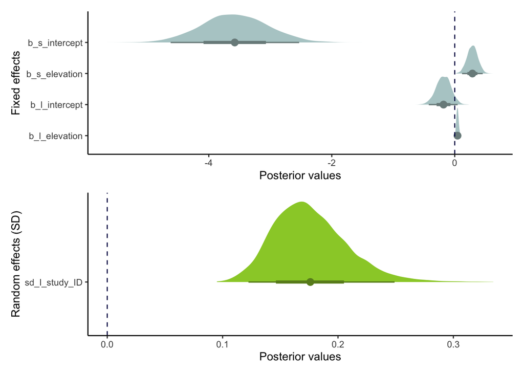

```r
# getting plots
plots_fit_mr3 <- list(
  visualize_fixed_effects(fit_mr3),
  visualize_random_effects(fit_mr3)
)

plots_fit_mr3[[1]] / plots_fit_mr3[[2]]
```

An alternative way to visualize the results:

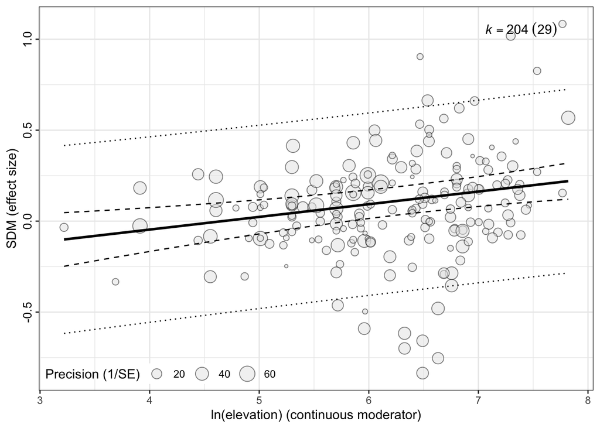

```r
mr3_mod <- rma.mv(yi = yi,
                  V =  vcv,
                  mod = ~ elevation_log,
                  random = list(~1 | study_ID,
                                ~1 | es_ID),
                  data = dat,
                  test = "t",
                  sparse = TRUE,
                  control=list(optimizer="optim", optmethod="Nelder-Mead")
)

bubble_plot(mr3_mod, mod = "elevation_log", group = "study_ID", g = TRUE,
            xlab = "ln(elevation) (continuous moderator)",
            ylab = "SDM (effect size)",
            legend.pos = "bottom.left")
```

#### 7.2.3.2 `blsmeta`

The `blsmeta` is also capable of fitting a multilevel location-scale meta-regression with a continuous moderator.

The syntax is as follow:

```r
dat$study_ID <- as.numeric(dat$study_ID)
fit_mr33 <- blsmeta(yi = yi,
                    vi = vi,
                    es_id = es_ID,
                    study_id = study_ID,
                    mods = ~ 1 + elevation_log,
                    mods_scale2 = ~ 1 + elevation_log,
                    data = dat)
#save
saveRDS(fit_mr33, here("Rdata", "fit_mr33.rds"))
```

```r
# read in rds
fit_mr33 <- readRDS(here("Rdata", "fit_mr33.rds"))
print(fit_mr33)
## Model: Three-Level
## Studies2: 204
## Studies3: 29
## Samples: 20000 (4 chains)
## Location Formula: ~ 1 + elevation_log
## Scale2 Formula: ~ 1 + elevation_log
## Scale3 Formula: ~ 1
## Note: 'Scale' on standard deviation scale
## ------
## Scale2:
##               Post.mean Post.sd Cred.lb Cred.ub Rhat
## (Intercept)       -3.57    0.56   -4.61   -2.43 1.01
## elevation_log      0.29    0.09    0.10    0.45 1.00
##
## Scale3:
##               Post.mean Post.sd Cred.lb Cred.ub Rhat
## sd(Intercept)      0.17    0.03    0.12    0.23 1.05
##
## Location:
##               Post.mean Post.sd Cred.lb Cred.ub Rhat
## (Intercept)       -0.19    0.11   -0.43    0.02 1.20
## elevation_log      0.05    0.02    0.01    0.08 1.01
##
## ------
## Date: Fri Apr 18 16:06:25 2025
```

The differences are expected to be caused by the different priors and MCMC samplers used in `brms` and `lsmeta`. However, if we back-transform the estimate to its original scale (raw variance), the results become very similar.

## 7.3 Example 3: Publication Bias (Small-Study, Decline, Proteus)

### 7.3.1 Data

We use the data (hereafter **Example 3**) from the following paper:

> Neuschulz, E. L. et al. (2016). Pollination and seed dispersal are the most threatened processes of plant regeneration. Scientific Reports, 6, 29839.

This data were originally used to study the effect of forest disturbance on pollination, seed dispersal, seed predation, recruitment and herbivore during plant regeneration. Now, we will use it to illustrate the proposed four types of publication bias, including small-study effect, decline effect, small-study divergence, and Proteus effect. While the first two (Equations (35)) are relevant to the location part of the location-scale meta-analysis, the last two (Equation (36)) are relevant to the scale part of the location-scale meta-analysis.

Let’s load the data (`seed.csv`) and have basic data cleaning:

```r
dat <- read.csv(here("data", "seed.csv"))
dat$study_ID <- as.factor(dat$study)
dat$es_ID <- as.factor(1:nrow(dat))
dat$se <- sqrt(dat$var.eff.size) # SE (sampling error SD)
dat$smd <- dat$eff.size # effect isze
dat$cyear <- scale(dat$study.year, center = TRUE, scale = FALSE) # centred year
# select varaibles we need
dat <- dat %>% select(smd, var.eff.size, es_ID, study_ID, se, cyear)
str(dat)
## 'data.frame':    98 obs. of  6 variables:
##  $ smd         : num  -0.65 2.24 -1.39 -1.08 0.42 0.34 -0.05 -5.53 -1.07 -0.46 ...
##  $ var.eff.size: num  0.6 0.23 0.17 0.16 0.14 0.14 0.13 0.52 0.49 0.42 ...
##  $ es_ID       : Factor w/ 98 levels "1","2","3","4",..: 1 2 3 4 5 6 7 8 9 10 ...
##  $ study_ID    : Factor w/ 40 levels "Albrecht et al. 2012",..: 34 20 20 20 20 20 20 33 40 40 ...
##  $ se          : num  0.775 0.48 0.412 0.4 0.374 ...
##  $ cyear       : num [1:98, 1] -13.59 -7.59 -7.59 -7.59 -7.59 ...
##   ..- attr(*, "scaled:center")= num 2008
```

The key variables are:

`smd`: effect size estimates, quantifying the sign and magnitude of the effect of forest disturbance

`var.eff.size`: sampling variance corresponding to `smd`

`se`: standard error (square root of `var.eff.size`), which will be used as the moderator of the small-study effect and small-study divergence

`cyear`: publication year (centered) of each study, which will be used as the moderator of the decline effect, and Proteus effect